# R Notebook

# 0. Observational data analysis

## Sites:

Observational data - 38 sites with pretrt soil data and a full compliment of 30 plots and 3 blocks

## Questions:

1. Do we see differences in species occupancy within sites just based on observational data and variation in soil resources? Drawing on Lewandowska 2016 and the observational side of Harpole 2007.

Ordination of observational species matrix and seeing the explanatory power of Z-scores in variation of N,P,K.

2. Start with observations – here’s a bunch of sites with 30 plots, do you see some of the same kind of trade-offs among species in plots within a block?

## Response:

Log-response ratio of community variables in observational plots

## Outcomes:

## Analysis:

Reading in data and subsetting data files to include sites that contain pre-treatment soil data.

```r
sites_toselect
```

```
 [1] "amcamp.us"   "azi.cn"      "bari.ar"     "barta.us"    "bnch.us"     "bogong.au"   "bttr.us"
 [8] "bunya.au"    "burrawan.au" "cereep.fr"   "chilcas.ar"  "cowi.ca"     "derr.au"     "elliot.us"
[15] "frue.ch"     "gilb.za"     "glac.us"     "hall.us"     "hart.us"     "hnvr.us"     "kiny.au"
[22] "lead.us"     "look.us"     "ping.au"     "pinj.au"     "potrok.ar"   "sage.us"     "sedg.us"
[29] "sereng.tz"   "sgs.us"      "sier.us"     "smith.us"    "spin.us"     "summ.za"     "trel.us"
[36] "ukul.za"     "unc.us"      "valm.ch"
```

```r
plot.sp.mat = plot.sp.mat %>% filter(site_code %in% sites_toselect)
# Subset by soil characteristics (must include pre-treatment data)
pretrt = soil.chars %>%
  filter(year_trt == 0) %>%
  group_by(site_code, block) %>%
  summarise(ndat = sum(!is.na(pct_N))) %>%
  filter(ndat > 0)
# Number of sites with pretrt soil data:
length(unique(pretrt$site_code))
```

```
[1] 63
```

```r
# Subsetting species matrix by these site codes
soil.chars = soil.chars[soil.chars$site_code %in% unique(pretrt$site_code), ] %>% filter(year_trt == 0)
plot.sp.mat = plot.sp.mat[plot.sp.mat$site_code %in% unique(pretrt$site_code), ]
plot.sp.mat = plot.sp.mat %>% filter(year_trt == 0)
soil.means = soil.chars %>% group_by(site_code) %>%
  select(c("pct_C", "pct_N", "ppm_P", "ppm_K", "ppm_Ca", "ppm_Mg", "ppm_S",
           "ppm_Na", "ppm_Zn", "ppm_Mn", "ppm_Fe", "ppm_Cu", "ppm_B", "pH")) %>%
  summarise_all(funs(mean = mean,
                     sd = sd))
soil.zscores = soil.chars %>% group_by(site_code, block, plot, trt, year, year_trt) %>%
  select(c("plot", "pct_C", "pct_N", "ppm_P", "ppm_K", "ppm_Ca", "ppm_Mg", "ppm_S",
           "ppm_Na", "ppm_Zn", "ppm_Mn", "ppm_Fe", "ppm_Cu", "ppm_B", "pH")) %>%
  left_join(soil.means, by = c("site_code")) %>%
  mutate(C_z = (pct_C - pct_C_mean) / pct_C_sd,
         N_z = (pct_N - pct_N_mean) / pct_N_sd,
         P_z = (ppm_P - ppm_P_mean) / ppm_P_sd,
         K_z = (ppm_K - ppm_K_mean) / ppm_K_sd,
         Ca_z = (ppm_Ca - ppm_Ca_mean) / ppm_Ca_sd,
         Mg_z = (ppm_Mg - ppm_Mg_mean) / ppm_Mg_sd,
         S_z = (ppm_S - ppm_S_mean) / ppm_S_sd,
         Na_z = (ppm_Na - ppm_Na_mean) / ppm_Na_sd,
         Zn_z = (ppm_Zn - ppm_Zn_mean) / ppm_Zn_sd,
         Mn_z = (ppm_Mn - ppm_Mn_mean) / ppm_Mn_sd,
         Fe_z = (ppm_Fe - ppm_Fe_mean) / ppm_Fe_sd,
         Cu_z = (ppm_Cu - ppm_Cu_mean) / ppm_Cu_sd,
         B_z = (ppm_B - ppm_B_mean) / ppm_B_sd,
         pH_z = (pH - pH_mean) / pH_sd
         )
alldat = inner_join(na.omit(soil.zscores), plot.sp.mat, by = c("site_code", "block", "plot", "year", "trt", "year_trt"))
alldat = bind_cols(alldat[,1:61], alldat[,62:ncol(alldat)][,colSums(alldat[,62:ncol(alldat)]) > 0])
# Subsetting data into two matrices
com.attr = alldat[,1:61]
com.mat = alldat[,62:ncol(alldat)]
# Checking dataframes
# head(com.mat)
# head(com.attr)
```

# What fraction of variance is explained by nutrient availability axes:

- Is a permutational ANOVA here the best choice again?
- Fraction of total variance that is explained by explained by N availability, P-availability, etc.?
- Or PCA?
- Axis loadings? Some sort of indirect gradient analysis?

```r
# For each site in the dataset:
  # Segment into blocks (if/if not)
  # Calculate site scores within each block
  # Indirect gradient analysis of N, P, and K on
  # Pull out individual site scores within each block for each of the three nutrients (N, P, and K)
  # Also pull out total variation explained by each axis (constrained vs not) + significance
  # Correlations between axes?
# What are the best ways to look at multi-block variation?
# Alternatively, could do the same using CCA
output <- list()
counter <- 1
# For all unique sites selected
for(i in unique(com.attr$site_code)){

    # Subset to a single site
    com.subset <- com.mat[com.attr$site_code == i & com.attr$year_trt == 0,]

    # Remove all zero columns
    com.subset = com.subset[,colSums(com.subset) > 0]

    # Pull out relevant plot attributes for each site
    attr.subset <- data.frame(com.attr) %>% filter(site_code == i & year_trt == 0)

    # Check that these two matrices are the same size
    expect_true(nrow(attr.subset) == nrow(com.subset))

    # Standardizing community data matrix (normalized, in this case)
    mat.stdized <- decostand(com.subset, "total")

    # Running CCA on this data with the 3 axes of environmental variation (N, P, K)
    cca.mod = cca(mat.stdized ~ (N_z + P_z + K_z) , data = attr.subset)

    # Saving ouput
    output[[counter]] = list(sitename = i,
                               block = 1,
                               envscores = calibrate(cca.mod),
                               varexp = data.frame(mod = anova(cca.mod)$ChiSquare[1],
                                                   resid = anova(cca.mod)$ChiSquare[2],
                                                   dfmod = anova(cca.mod)$Df[1],
                                                   dfresid = anova(cca.mod)$Df[2],
                                                   pval = anova(cca.mod)$"Pr(>F)"[1]
                                                  ),
                               envvifs = vif.cca(cca.mod))

      # Update counter
      counter = counter + 1

}
```

# Are measures of N, P, and K correlated with one another?

Yes, measures of soil fertility seem to be weakly correlated with one another within a given site

```r
cor(com.attr$N_z, com.attr$P_z);cor(com.attr$N_z, com.attr$K_z);cor(com.attr$K_z, com.attr$P_z)
```

```
[1] 0.2771441
[1] 0.2290805
[1] 0.3634096
```

# What sites exhibit the greatest proportion of community variance explained by soil nutrient Z-scores?

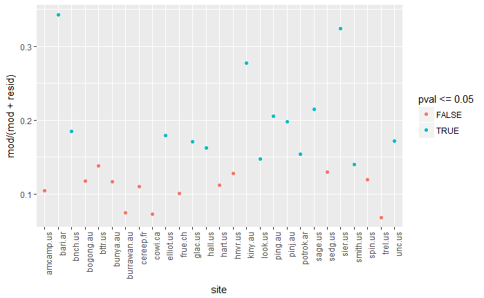

# What sites show the greatest amount of variance attributable to soil resource variation?

```r
car::Anova(lm(varfrac ~ CV_n * CV_p * CV_k, data = dat), type=2)
```

```
Anova Table (Type II tests)

Response: varfrac
                 Sum Sq Df F value  Pr(>F)
CV_n           0.027032  1  6.5488 0.01919 *
CV_p           0.000420  1  0.1017 0.75331
CV_k           0.003189  1  0.7726 0.39040
CV_n:CV_p      0.005392  1  1.3061 0.26729
CV_n:CV_k      0.001192  1  0.2887 0.59727
CV_p:CV_k      0.001042  1  0.2524 0.62119
CV_n:CV_p:CV_k 0.006047  1  1.4651 0.24097
Residuals      0.078428 19
---
Signif. codes:  0 ‘***’ 0.001 ‘**’ 0.01 ‘*’ 0.05 ‘.’ 0.1 ‘ ’ 1
```

# What to think about?

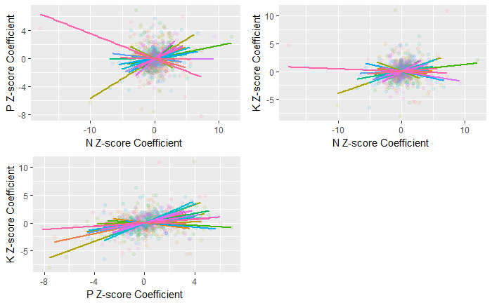

```r
p1 <- coefs %>%
  ggplot(aes(x = N_z, y = P_z, color = site)) +
  geom_point(alpha = .1) +
  guides(color = FALSE)+
  stat_smooth(method = "lm", se = FALSE) +
  xlab("N Z-score Coefficient ") +
  ylab("P Z-score Coefficient")
p2 <- coefs %>%
  ggplot(aes(x = N_z, y = K_z, color = site)) +
  geom_point(alpha = .1) +
  guides(color = FALSE)+
  stat_smooth(method = "lm", se = FALSE) +
  xlab("N Z-score Coefficient ") +
  ylab("K Z-score Coefficient")
p3 <- coefs %>%
  ggplot(aes(x = P_z, y = K_z, color = site)) +
  geom_point(alpha = .1) +
  guides(color = FALSE)+
  stat_smooth(method = "lm", se = FALSE) +
  xlab("P Z-score Coefficient ") +
  ylab("K Z-score Coefficient")
gridExtra::grid.arrange(p1, p2, p3, nrow = 2)
```

```r
cat(paste("N-P Corr:", cor(coefs$N_z, coefs$P_z),
      "\nN-K Corr:", cor(coefs$N_z, coefs$K_z),
      "\nP-K Corr:", cor(coefs$P_z, coefs$K_z)))
```

```
N-P Corr: 0.0960983831632756
N-K Corr: 0.103402424003949
P-K Corr: 0.300051700032506
```

```r
library(smatr)
modNP <- sma(N_z ~ P_z*site ,data=coefs, robust = TRUE)
sma.NP <- data.table(modNP$groupsummary) %>% select(-contains('test')) %>% rename(site=group) %>% mutate(slope.sig = (pval<0.05))
sma.NP <- left_join(sma.NP, coefs %>% group_by(site) %>% summarize(min.x = min(N_z,na.rm=T), max.x = max(P_z,na.rm=T))) %>% mutate(y.start = Slope * min.x + Int,y.end = Slope * max.x + Int)
```

```
Column `site` joining factor and character vector, coercing into character vector
```

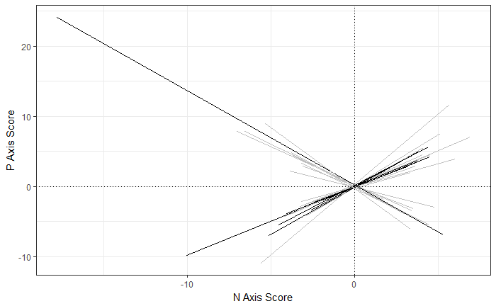

```r
ggplot(sma.NP,aes()) +
  geom_segment(aes(x=min.x,y=y.start,xend=max.x,yend=y.end,color=slope.sig)) +
  scale_color_manual(values=c('grey','black')) +
  geom_hline(yintercept=0,linetype='dotted') +
  geom_vline(xintercept=0,linetype='dotted') +
  theme_bw() + guides(color=F) +
  labs(x='N Axis Score',y='P Axis Score')
```

```r
modNK <- sma(N_z ~ K_z*site,data=coefs, robust = TRUE)
sma.NK <- data.table(modNK$groupsummary) %>% select(-contains('test')) %>% rename(site=group) %>% mutate(slope.sig = (pval<0.05))
sma.NK <- left_join(sma.NK, coefs %>% group_by(site) %>% summarize(min.x = min(N_z,na.rm=T), max.x = max(K_z,na.rm=T))) %>% mutate(y.start = Slope * min.x + Int,y.end = Slope * max.x + Int)
```

```
Column `site` joining factor and character vector, coercing into character vector
```

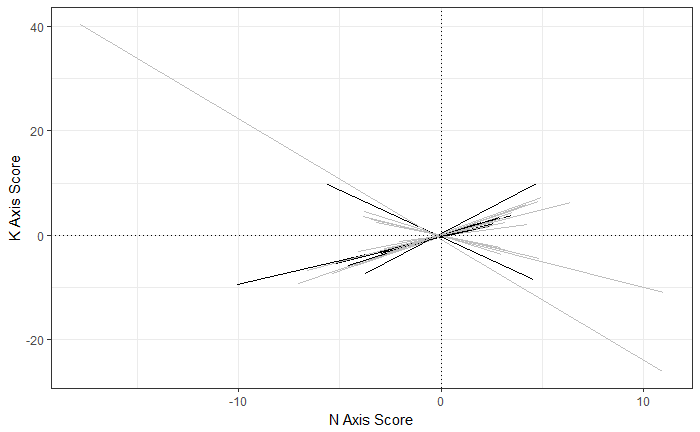

```r
ggplot(sma.NK,aes()) +
  geom_segment(aes(x=min.x,y=y.start,xend=max.x,yend=y.end,color=slope.sig)) +
  scale_color_manual(values=c('grey','black')) +
  geom_hline(yintercept=0,linetype='dotted') +
  geom_vline(xintercept=0,linetype='dotted') +
  theme_bw() + guides(color=F) +
  labs(x='N Axis Score',y='K Axis Score')
```

```r
modPK <- sma(P_z ~ K_z*site,data=coefs, robust = TRUE)
sma.PK <- data.table(modPK$groupsummary) %>% select(-contains('test')) %>% rename(site=group) %>% mutate(slope.sig = (pval<0.05))
sma.PK <- left_join(sma.PK, coefs %>% group_by(site) %>% summarize(min.x = min(P_z,na.rm=T), max.x = max(K_z,na.rm=T))) %>% mutate(y.start = Slope * min.x + Int,y.end = Slope * max.x + Int)
```

```
Column `site` joining factor and character vector, coercing into character vector
```

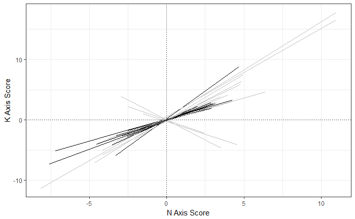

```r
ggplot(sma.PK,aes()) +
  geom_segment(aes(x=min.x,y=y.start,xend=max.x,yend=y.end,color=slope.sig)) +
  scale_color_manual(values=c('grey','black')) +
  geom_hline(yintercept=0,linetype='dotted') +
  geom_vline(xintercept=0,linetype='dotted') +
  theme_bw() + guides(color=F) +
  labs(x='N Axis Score',y='K Axis Score')
```